# Chap16

DeukjungKim

# 16장 벡터

## **16.1 들어가기**

1. 티블의 기초 객체인 벡터에 대해 알아야 한다.
2. 함수의 대부분은 벡터로 인하여 작동하기 때문 매우 중요.

### **16.1.1 준비하기**

purrr 패키지의 함수를 사용할 것

```r
library(tidyverse)
```

## **16.2 벡터의 기초**

- **원자벡터**: 6가지 유형

  1. 논리형(logical)  
  2. 정수형(integer)  
  3. 더블형(dou-ble)  
  4. 문자형(character)  
  5. 복소수형(character)  
  6. 원시형(raw)
- **리스트** = 재귀 벡터라고도 불리며 한 리스트가 다른 리스트를 포함할 수 있다.  
  <원자 벡터와 리스트의 차이점>

  ```
  1. 원자 벡터 = 동질적, 리스트 = 이질적
  2. NULL은 벡터가 없는 것을 나타내기 위해 종종 사용된다.
  ```

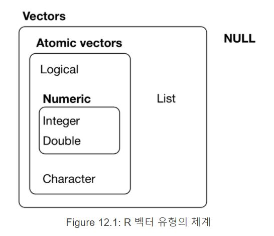

  모든 벡터는 두가지 주요 속성이 있다.
  - 유형 : typeof()로 확인할 수 있음.

  ```r
  typeof(letters)
  ```

  ```
  ## [1] "character"
  ```

  ```r
  typeof(1:10)
  ```

  ```
  ## [1] "integer"
  ```

  - 길이: length()로 확인할 수 있음.

  ```r
  x <- list("a", "b", 1:10)
  length(x)
  ```

  ```
  ## [1] 3
  ```

  임의의 추가 메타 데이터를 속성(attribute)형식으로 벡터에 포함시켜 확장 벡터를 만드는데 사용한다. 확장 벡터에는 네 가지 중요한 유형이 있다.
  - 팩터형은 정수형 벡터를 기반으로 만들어졌다.
  - 데이트형과 데이트-타임형은 수치형 벡터를 기반으로 만들어졌다.
  - 데이터프레임과 티블은 리스트를 기반으로 만들어졌다.

## **16.3 원자 벡터의 주요 유형**

### **16.3.1 논리형**

- FALSE, TRUE, NA 세 가지 값만 사용 할 수 있기에 가장 단순한 원자 벡터이다.
- 비교 연산자로 생성
- c()를 사용하여 직접 생성할 수도 있다.

```r
1:10 %% 3 == 0
```

```
##  [1] FALSE FALSE  TRUE FALSE FALSE  TRUE FALSE FALSE  TRUE FALSE
```

```r
c(TRUE, TRUE, FALSE, NA)
```

```
## [1]  TRUE  TRUE FALSE    NA
```

### **16.3.2 수치형**

- 정수형 + 더블형 = 수치형 벡터
- R에서 숫자는 기본값으로 더블형이다.
- 정수형으로 만들려면 숫자 뒤에 **L**을 붙이면 된다.

```r
typeof(1)
```

```
## [1] "double"
```

```r
typeof(1L)
```

```
## [1] "integer"
```

```r
1.5L
```

```
## [1] 1.5
```

정수형과 더블형을 구분하는 게 일반적으로 중요하지 않지만 두 가지 중요한 차이점을 알고 있어야 한다.

- 더블형은 근사값이다. 더블형은 부동 소수점 수를 나타내는데 고정된 크기의 메모리로 이를 매번 정확히 표현할 수는 없다. 즉, 더블형 값은 모두 근사치로 간주해야 한다.

```
예를 들어 2의 제곱근의 제곱은 무엇일까?
```

```r
x <- sqrt(2) ^ 2
x
```

```
## [1] 2
```

```r
x - 2
```

```
## [1] 4.440892e-16
```

즉, 대부분의 계산에는 근사 오차가 포함된다. ==를 사용하여 부동 소수점 수를 비교하는 대신 dplyr::near()를 사용해야 한다. 그러면 수치상 오차가 허용된다.

- 정수형에는 특수한 값이 NA 한 개가 있음
- 더블형에는 NA, NaN, Inf, 및 -Inf가 있다.
- 이 모든 수치들은 나눗셈에서 발생할 수 있다.

```r
c(-1, 0, 1) / 0
```

```
## [1] -Inf  NaN  Inf
```

이러한 특수한 값을 확인할 목적으로 ==을 사용하면 안 된다.  
대신 도우미 함수

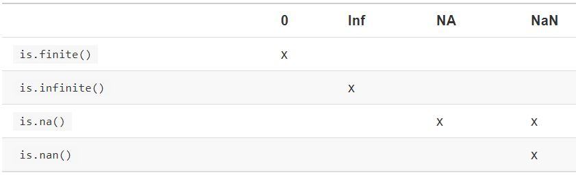

### **16.3.3 문자형**

문자형 벡터는 각 요소가 문자열이기 때문에 가장 복잡한 유형의 원자 벡터이다.

- 문자열 구현에 있어서 중요한 특징 중 하나
- R은 전역 문자열 풀을 사용한다. -> 고유 문자열은 메모리에 한 번만 저장되며 문자열을 사용할때 마다 해당 표현을 포인트한다.

```
pryr::object_size()를 사용하여 이 동작을 직접 볼 수 있다.
```

```r
x <- "적당히 긴 문자열입니다"
pryr::object_size(x)
```

```
## 136 B
```

```r
y <- rep(x, 1000)
pryr::object_size(y)
```

```
## 8.13 kB
```

### **16.3.4 결측값**

각 유형의 원자 벡터에는 고유한 결측값이 있다.

```r
NA            # 논리형
```

```
## [1] NA
```

```r
NA_integer_   # 정수형
```

```
## [1] NA
```

```r
NA_real_      # 더블형
```

```
## [1] NA
```

```r
NA_character_ # 문자형
```

```
## [1] NA
```

## **16.3 원자 벡터 이용하기**

여러 유형의 원자 벡터를 이해했으므로 이제 함께 사용할 수 있는 도구들을 검토하는 것이 좋다.

- 한 유형에서 다른 유형으로 변환시키는 법, 자동으로 변환되는 조건.
- 한 객체가 특정 유형 벡터인지 알아보는 법.
- 다른 길이의 벡터들로 작업할 때 발생하는 일.
- 벡터의 요소를 이름 짓는 법.
- 관심 있는 요소를 추출하는 법.

### **16.4.1 강제 변환**

한 유형 벡터에서 다른 유형으로 강제 변환하는 방법은 두 가지이다.

- 명시적 강제 변환은 `logical()`, `as.integer()`, `as.double()`, `as.character()`와 같은 함수를 호출할 때 발생

```
명시적 강제 변환이 필요한 경우
 -readr의 col_types 명세를 조정해야 할 수도 있다.
```

- 암묵적 강제 변환은 특정 유형의 벡터가 필요한 상황에서 어떤 다른 벡터를 사용하는 경우 발생한다.

```
수치형 요약 함수에 논리형 벡터를 사용하거나 정수형 벡터가 예상되는 곳에 더블형 벡터를 사용 하는 경우이다.
```

이미 암묵적 강제 변환을 보았다. -> 수치형 문제에서 논리형 벡터를 사용 했던 것이다.

```r
x <- sample(20, 100, replace = TRUE)
y <- x > 10
sum(y) # 10보다 큰 것의 개수?
```

```
## [1] 38
```

```r
mean(y) # 10보다 큰 비율?
```

```
## [1] 0.38
```

반대 방향, 즉 정수형에서 논리형으로의 암시적 강제 변환에 의존하는 코드도 볼 수 있다.

```r
if (length(x)) {
  # 어떤 작업
}
```

이렇게 하면 코드를 이해하기가 더 어렵게 된다고 생각하기 때문에 이를 권장하지 않는다.

```
length(x) > 0
```

또한 **c()**로 여러 유형을 포함하는 벡터를 만들려고 할 때 다음과 같은 일이 일어난다는 것을 이해하는 것도 중요하며 가장 복잡한 유형으로 변환된다.

```r
typeof(c(TRUE, 1L))
```

```
## [1] "integer"
```

```r
typeof(c(1L, 1.5))
```

```
## [1] "double"
```

```r
typeof(c(1.5, "a"))
```

```
## [1] "character"
```

벡터의 유형은 개별요소가 아닌 전체 벡터의 특성, 한 원자 벡터의 유형이 여러 개일 수는 없다.  
동일한 벡터에서 여러 유형을 혼합해야 하는 경우에는 리스트를 사용하면 된다.

### **16.4.2 테스트 함수**

1. typeof()를 사용하는 것
2. TRUE 또는 FALSE를 반환하는 테스트 함수를 사용하는 것 `purrr이 제공하는 is_* 함수를 사용하는 것이 더 안전하다`

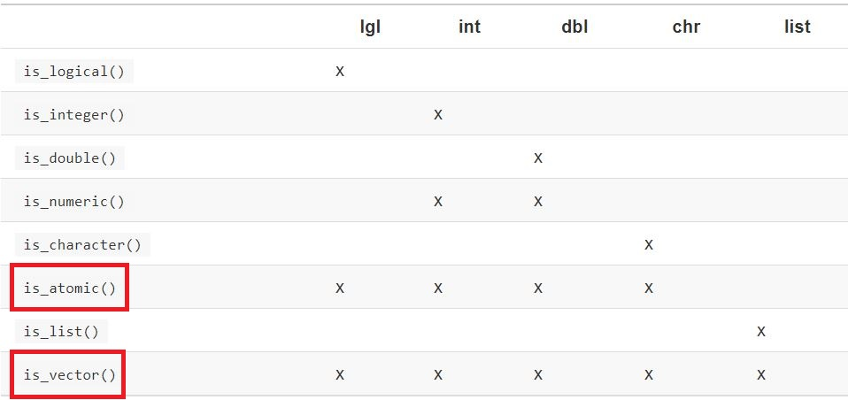

   `위의 각 함수마다 is_scalar atomic()과 같은 '스칼라' 버전이 있는데 이는 길이가 1인지 확인한다.`

### **16.4.3 스칼라와 재활용 규칙**

- 짧은 벡터가 긴 벡터의 길이로 반복되거나 재활용되므로 이를 **벡터 재활용**이라고 한다.
- 벡터 재활용은 벡터와 ’스칼라’를 혼합할 때 매우 유용하다.
- 사실 R에서는 스칼라가 존재하지 않는다.
- 스칼라가 없으므로 대부분의 내장 함수는 벡터화(즉, 수치 벡터에서 작동)된다.

```
예로 든 코드이다
```

```r
sample(10) + 100
```

```
##  [1] 102 110 109 107 108 101 103 106 105 104
```

```r
runif(10) > 0.5
```

```
##  [1]  TRUE FALSE  TRUE  TRUE  TRUE FALSE  TRUE FALSE FALSE FALSE
```

같은 길이의 두 벡터 또는 벡터와 ’스칼라’를 더할 경우 일어나야 하는 일은 직관적이다.

```
but 길이가 다른 두 개의 벡터를 더하면 어떻게 되는가?
```

```r
1:10 + 1:2
```

```
##  [1]  2  4  4  6  6  8  8 10 10 12
```

여기에서 R은 가장 짧은 벡터를 가장 긴 벡터 길이로 확장함 -> 이것을 **재활용**이라고 부른다.

```r
1:10 + 1:3
```

```
##  [1]  2  4  6  5  7  9  8 10 12 11
```

벡터 재활용을 사용하면 매우 간결하고 영리한 코드를 작성할 수 있지만 조용히 문제가 숨겨질 수도 있다. 재활용을 하고싶다면 **rep()**으로 직접 처리해야 한다.

```
tibble(x = 1:4, y = 1:2)
#> Error: colum 'y' must be length 1 or 4, not 2
```

```r
tibble(x = 1:4, y = rep(1:2, 2))
```

```
## # A tibble: 4 x 2
##       x     y
##   <int> <int>
## 1     1     1
## 2     2     2
## 3     3     1
## 4     4     2
```

```r
tibble(x = 1:4, y = rep(1:2, each = 2))
```

```
## # A tibble: 4 x 2
##       x     y
##   <int> <int>
## 1     1     1
## 2     2     1
## 3     3     2
## 4     4     2
```

### **16.4.4 벡터 이름 짓기**

모든 유형의 벡터는 이름을 지정할 수 있다. c()를 사용하여 생성 시 이름을 지정할 수 있다.

```r
c(x = 1, y = 2, z = 3)
```

```
## x y z
## 1 2 3
```

또는 생성 이후에 purrr::set_names()으로 이름을 지정할 수도 있다.

```r
setNames(1:3, c("a", "b", "c"))
```

```
## a b c
## 1 2 3
```

명명된 벡터는 서브셋할 때 매우 유용하며 다음에 설명된다.

### **16.4.5 서브셋 하기**

지금까지 dplyr::filter()를 사용하여 티블의 행을 필터링했다.  
filter()는 티블에서만 작동하기 때문에 벡터용 도구가 새로 필요하다 -> [ 이다  
[ 은 서브셋 하는 함수이며 **x[a]**와 같이 호출된다.

- 정수형만 포함하는 수치형 벡터

```r
x <- c("one", "two", "three", "four", "five")
x[c(3, 2, 5)]
```

```
## [1] "three" "two"   "five"
```

위치를 반복하면 실제로 입력보다 긴 출력을 만들 수 있다.

```r
x[c(1, 1, 5, 5, 5, 2)]
```

```
## [1] "one"  "one"  "five" "five" "five" "two"
```

음수값은 해당 위치의 요소를 누락시킨다.

```r
x[c(-1, -3, -5)]
```

```
## [1] "two"  "four"
```

양수값과 음수값을 혼합하면 오류이다.

```
x[c(1, -1)]
#> Error in x[c(1, -1)]
#> only 0's may be mixed with negative subscripts
```

다음의 오류 메시지는 0으로 서브셋했기 때문에 아무 값도 반환하지 않았음을 나타낸다.

```r
x[0]
```

```
## character(0)
```

- 논리형 벡터로 서브셋하면 TRUE 값에 해당하는 모든 값이 유지된다.

```r
x <- c(10, 3, NA, 5, 8, 1, NA)

# x 중 결측값이 아닌 모든 값
x[!is.na(x)]
```

```
## [1] 10  3  5  8  1
```

```r
# x 중 모든 짝수(혹은 결측값!)
x[x %% 2 == 0]
```

```
## [1] 10 NA  8 NA
```

- 명명된 벡터가 있다면 이를 문자형 벡터로 서브셋할 수 있다.

```r
x <- c(abc = 1, def = 2, xyz = 5)
x[c("xyz", "def")]
```

```
## xyz def
##   5   2
```

- 가장 간단한 서브셋 동작은 x[ ]이며, 전체 x를 반환한다.
- [ 의 변형 [[ 이다. [[ 은 오직 하나의 요소만 추출하고 항상 이름을 누락시킨다.

## **16.5 재귀 벡터(리스트)**

- 다양한 종류의 데이터를 가지는 데이터 묶음
- 리스트 자료형 자체도 데이터로 가질 수 있음
- 그래서 **재귀형(recursive)**라고도 표현함
- 원자 벡터 생성 : `c()` 함수 사용 (c = combin의 약자)
- 리스트 생성 : `list()` 함수 사용
- 이중 대괄호와 대괄호가 있는 형태

```r
x <- list(1, 2, 3)
x
```

```
## [[1]]
## [1] 1
##
## [[2]]
## [1] 2
##
## [[3]]
## [1] 3
```

- str() 함수를 사용하여 어떤 구조인지 확인

```r
str(x)
```

```
## List of 3
##  $ : num 1
##  $ : num 2
##  $ : num 3
```

```r
x_named <- list(a = 1,b = 2,c = 3)
str(x_named)
```

```
## List of 3
##  $ a: num 1
##  $ b: num 2
##  $ c: num 3
```

- 원자 벡터와 다르게 `list()`는 객체들을 혼합하여 포함할 수 있다.

```r
y <- list("a", 1L, 1.5, TRUE)
str(y)
```

```
## List of 4
##  $ : chr "a"
##  $ : int 1
##  $ : num 1.5
##  $ : logi TRUE
```

- 리스트는 다른 리스트를 포함할 수도 있다.

```r
z <- list(list(1, 2), list(3, 4))
str(z)
```

```
## List of 2
##  $ :List of 2
##   ..$ : num 1
##   ..$ : num 2
##  $ :List of 2
##   ..$ : num 3
##   ..$ : num 4
```

### **16.5.1 리스트 시각화**

복잡한 리스트는 시각적으로 표현하는 것이 편리하다.

```r
x1 <- list(c(1, 2), c(3, 4))
x2 <- list(list(1, 2), list(3, 4))
x3 <- list(1, list(2, list(3)))
```

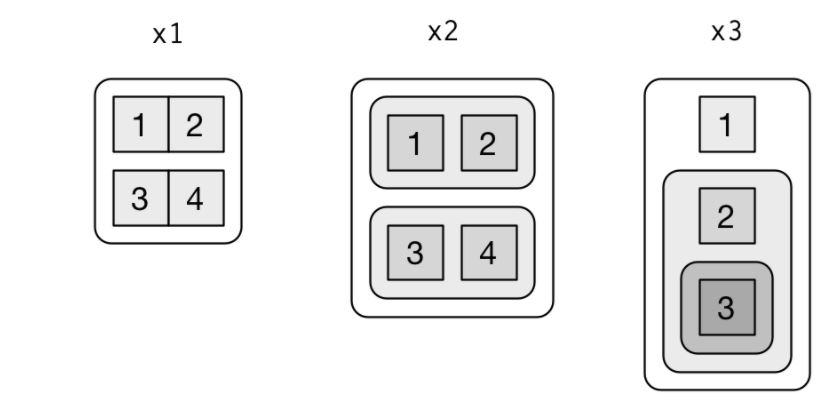

3가지 원칙이 있다.

1. 리스트는 모서리가 둥글다. 원자 벡터는 모서리가 사각이다.
2. 자식은 부모 내부에 그려지며 계층을 쉽게 볼 수 있게 배경이 약간 더 어둡다.
3. 자식의 방향(즉, 행 또는 열)은 중요하지 않으므로 공간을 절약하거나 예제에서 중요한 속성을 잘 설명할 수 있는 행 또는 열 방향을 선택한다.

### **16.5.2 서브셋하기**

리스트 서브셋하는 방법은 세 가지이다. 예시로 어떤 리스트가 a라 하자.

```r
a <- list(a = 1:3, b = "a string", c = pi, d = list(-1, -5))
```

- [ 는 부분 리스트를 추출한다. 결과는 항상 리스트이다.

```r
str(a[1:2])
```

```
## List of 2
##  $ a: int [1:3] 1 2 3
##  $ b: chr "a string"
```

```r
str(a[4])
```

```
## List of 1
##  $ d:List of 2
##   ..$ : num -1
##   ..$ : num -5
```

벡터에서와 같이 논리형, 정수형, 문자형 벡터로 서브셋할 수 있다.

- [[ 는 리스트의 단일 구성요소를 추출한다. 리스트의 계층구조에서 한 레벨을 제거한다.

```r
str(a[[1]])
```

```
##  int [1:3] 1 2 3
```

```r
str(a[[4]])
```

```
## List of 2
##  $ : num -1
##  $ : num -5
```

- $는 리스트의 명명된 요소를 추출하는 단축문자이다. 이는 따옴표가 필요없다는 것을 제외하고는 [[ 와 유사하게 동작한다.

```r
a$a
```

```
## [1] 1 2 3
```

```r
a[["a"]]
```

```
## [1] 1 2 3
```

[ 와 [[ 의 차이는 리스트에 있어서 정말 중요하다. [[ 는 리스트 안으로 내려가는 반면 [ 는 더 작은 새 리스트를 반환하기 때문이다.

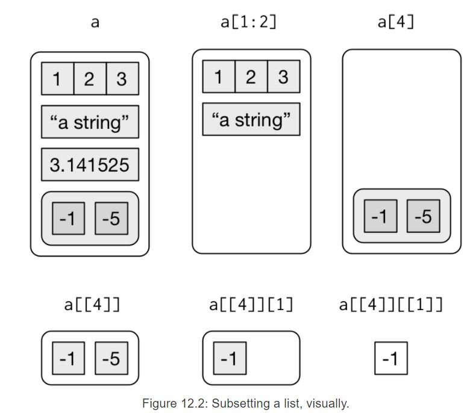

### **16.5.3 조미료 리스트**

[ 와 [[ 의 차이점은 매우 중요. 헷길리기 쉬움으로 후추통으로 비유해보자

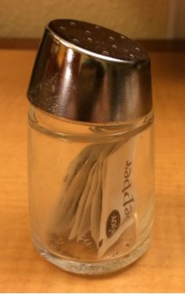

이 후추통이 리스트 x라고 한다면 x[1]은 후추팩 하나가 들어있는 후추통이다.

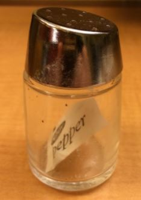

x[2]는 똑같지만, 두 번째 팩을 포함한다. x[1:2]는 후추팩 두 개가 들어있는 후추통이다.  
x[[1]]은 후추팩 하나이다.

[figure not shown]

후추팩의 내용물은 x[[1]][[1]]으로 얻을 수 있다.

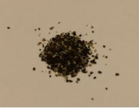

## **16.6 속성**

- 확장 벡터는 속성을 가짐
- 속성(attribute): 메타 데이터(“데이터의 데이터”)
- `attr()` 함수를 사용하여 가져오거나 attributes()로 한번에 모두 볼 수 있다.

```r
x <- 1:10
attr(x, "greeting")
```

```r
attr(x, "greeting") <- "Hi!"
attr(x, "farewell") <- "Bye"
attributes(x)
```

```
## $greeting
## [1] "Hi!"
##
## $farewell
## [1] "Bye"
```

R의 기본 부분을 구현하는데 세 가지 매우 중요한 속성이 사용되었다.

- Names는 벡터 요소의 이름을 지정하는 데 사용된다.
- Dimensions(줄여서 dims)는 벡터를 행렬이나 어레이 같이 동작하도록 만든다.
- Class는 S3 객체지향 시스템을 구현하는데 사용된다.

Class는 제네릭 함수의 작동 방식을 제어한다.  
일반적인 제너릭 함수는 다음과 같다.

```r
as.Date
```

```
## function (x, ...)
## UseMethod("as.Date")
## <bytecode: 0x00000000116ec238>
## <environment: namespace:base>
```

‘UseMethod’ 호출은 이 함수가 제네릭 함수임을 의미하여 첫 번째 인수의 클래스를 기반으로 특정함수(메소드)를 호출한다. (모든 메소드는 함수이지만 모든 함수가 메서드인 것은 아니다.) methods()를 사용하여 제네릭의 모든 메서드를 나열할 수 있다.

```r
methods("as.Date")
```

```
## [1] as.Date.character   as.Date.default     as.Date.factor
## [4] as.Date.numeric     as.Date.POSIXct     as.Date.POSIXlt
## [7] as.Date.vctrs_sclr* as.Date.vctrs_vctr*
## see '?methods' for accessing help and source code
```

예를 들어 x가 문자형 벡터이면 as.Date()는 as.Date.character()를 호출하고 팩터형이면 as.Date.factor()를 호출한다.  
getS3method()로 메서드의 구현을 구체적으로 볼 수 있다.

```r
getS3method("as.Date", "default")
```

```
## function (x, ...)
## {
##     if (inherits(x, "Date"))
##         x
##     else if (is.null(x))
##         .Date(numeric())
##     else if (is.logical(x) && all(is.na(x)))
##         .Date(as.numeric(x))
##     else stop(gettextf("do not know how to convert '%s' to class %s",
##         deparse1(substitute(x)), dQuote("Date")), domain = NA)
## }
## <bytecode: 0x00000000156a8628>
## <environment: namespace:base>
```

```r
getS3method("as.Date", "numeric")
```

```
## function (x, origin, ...)
## {
##     if (missing(origin)) {
##         if (!length(x))
##             return(.Date(numeric()))
##         if (!any(is.finite(x)))
##             return(.Date(x))
##         stop("'origin' must be supplied")
##     }
##     as.Date(origin, ...) + x
## }
## <bytecode: 0x00000000149d3668>
## <environment: namespace:base>
```

가장 중요한 S3 제네릭은 print()인데 이는 콘솔에서 이름이 타이핑되었을때 객체가 출력되는 방식을 조정한다. 다른 중요한 제네릭은 서브넷 동작 함수들인 [,[[, $이다.

## **16.7 확장 벡터**

확장벡터는 클래스를 가지므로 원자 벡터와 다르게 동작한다.

- 팩터형
- 데이트형
- 데이트-타임형
- 티블

### **16.7.1 팩터형**

- 팩터형은 범주형 데이터를 표현하기 위해 설계되었다.
- 팩터형은 정수형을 기반으로 만들어졌고 레벨 속성을 갖는다.

```r
x <- factor(c("ab", "cd", "ab"), levels = c("ab", "cd", "ef"))
typeof(x)
```

```
## [1] "integer"
```

```r
attributes(x)
```

```
## $levels
## [1] "ab" "cd" "ef"
##
## $class
## [1] "factor"
```

### **16.7.2 데이트형과 데이트-타임형**

R의 데이트형은 1970년 1월 1일부터 지난 일 수를 나타내는 수치형 벡터이다.

```r
x <- as.Date("1971-01-01")
unclass(x)
```

```
## [1] 365
```

```r
typeof(x)
```

```
## [1] "double"
```

```r
attributes(x)
```

```
## $class
## [1] "Date"
```

데이트-타임형은 1970년 1월 1일부터 지난 초 수를 나타내는 POSIXct 클래스를 가진 수치형 벡터이다.

```
'POSIXct'는 Portable Operating System Interface calendar time을 의미한다.
```

```r
x <- lubridate::ymd_hm("1970-01-01 01:00")
unclass(x)
```

```
## [1] 3600
## attr(,"tzone")
## [1] "UTC"
```

```r
typeof(x)
```

```
## [1] "double"
```

```r
attributes(x)
```

```
## $class
## [1] "POSIXct" "POSIXt"
##
## $tzone
## [1] "UTC"
```

tzone 속성은 선택사항이다. 이것은 시간이 출력되는 방식을 제어하는 것이지 절대 시간을 제어하는 것이 아니다.

```r
attr(x, "tzone") <- "US/Pacific"
x
```

```
## [1] "1969-12-31 17:00:00 PST"
```

```r
attr(x, "tzone") <- "US/Eastern"
x
```

```
## [1] "1969-12-31 20:00:00 EST"
```

데이트-타임형의 또 다른 유형은 POSIXlt라고 부르는 것이다. 이는 명명된 리스트를 기반으로 만들어졌다.

```r
y <- as.POSIXlt(x)
typeof(y)
```

```
## [1] "list"
```

```r
attributes(y)
```

```
## $names
##  [1] "sec"    "min"    "hour"   "mday"   "mon"    "year"   "wday"   "yday"
##  [9] "isdst"  "zone"   "gmtoff"
##
## $class
## [1] "POSIXlt" "POSIXt"
##
## $tzone
## [1] "US/Eastern" "EST"        "EDT"
```

POSIXlt는 tidyverse 내부에서 거의 쓰지 않는다.

### **16.7.3 티블**

- 티블은 확장형 리스트이다.
- 세 가지 클래스인 **tbl_df**, **tbl**, **data.frame**을 갖는다.
- 두 가지 속성인 names(열 이름)와 row.names(행이름)를 갖는다.

```r
tb <- tibble::tibble(x = 1:5, y = 5:1)
typeof(tb)
```

```
## [1] "list"
```

```r
attributes(tb)
```

```
## $names
## [1] "x" "y"
##
## $row.names
## [1] 1 2 3 4 5
##
## $class
## [1] "tbl_df"     "tbl"        "data.frame"
```

전통적인 데이터프레임은 매우 유사한 구조를 가지고 있다.

```r
df <- data.frame(x = 1:5, y = 5:1)
typeof(df)
```

```
## [1] "list"
```

```r
attributes(df)
```

```
## $names
## [1] "x" "y"
##
## $class
## [1] "data.frame"
##
## $row.names
## [1] 1 2 3 4 5
```

- 여기서의 차이점은 클래스이다. 티블의 클래스는 ’data.frame’을 포함하는데 이는 티블이 기본값으로 일반적인 데이터프라임 동작을 물려받음을 의미한다.
- 티블 데이터프라임과 리스트의 차이점은 모든 요소는 길이가 같은 벡터이어야 한다는 점이다.